# Homework 1

Author

August

For the problems in which calculations are needed, please include your R code with your answers, otherwise you will not be given full credit. Please upload your assignment by Wednesday, September 10, 6 pm in a html/pdf file to Sakai.

1. In a simple linear regression problem where $n=30$, we obtain
   $$\sum_{i=1}^n x_i = 60, \sum_{i=1}^n y_i = 90, \sum_{i=1}^n x_i^2 = 240, \sum_{i=1}^n y_i^2 = 540, \sum_{i=1}^n x_iy_i = 234.$$
- Calculate $\hat{\beta}_0$ and $\hat{\beta}_1$.

```r
n <- 30
sum_x <- 60
sum_y <- 90
sum_x2 <- 240
sum_y2<- 540
sum_xy <- 234
xbar <- sum_x/n
ybar <- sum_y/n
beta1 <- (sum_xy - n*xbar*ybar) / (sum_x2 - n*xbar^2)
beta0 <- ybar - beta1*xbar

beta1
```

```
[1] 0.45
```

```r
beta0
```

```
[1] 2.1
```

- $\hat{\beta_1}$ = 0.45 & $\hat{\beta_0}$ = 2.1
- Calculate $\hat{\sigma}^2$ under both maximum likelihood and least squares methods.

```r
#Residual sum of squares
RSS<- sum_y2 +n*beta0^2 +beta1^2*sum_x2 - 2*beta0*sum_y -2*beta1*sum_xy + 2*beta0*beta1*sum_x
#maximum likelihood
sigma2_mle <- RSS / n
sigma2_mle
```

```
[1] 8.19
```

```r
#least squares (aka unbiased variance)
sigma2_ls <- RSS / (n-2)
sigma2_ls
```

```
[1] 8.775
```

- $\hat{o^2} MLE = 8.190$
- $\hat{o^2} LSE = 8.775$
- Calculate a test statistic $t$ and p-value for a hypothesis test for a significant linear relationship between $X$ and $Y$.
- $t = 1.664$ & $p = 0.1072$

```r
#standard error of beta1
SS_x <- sum_x2 - n*xbar^2
SE_B1 <- sqrt(sigma2_ls/ SS_x)
#t-statistic
t_stat <- beta1 / SE_B1
t_stat
```

```
[1] 1.664101
```

```r
#pvalue (two sided)
p_value <- 2* pt(-abs(t_stat),n-2)
p_value
```

```
[1] 0.1072459
```

```r
#we cannot reject the null hypothesis
```

2. Consider the dataset lifeexp in the Data folder attached to this assignment. Suppose we wish to predict life expectancy using different covariates (independent variables) in the dataset.
- Draw a scatterplot of life expectancy by income composition of resources (ICOR). Comment on the scatterplot.
- The scatterplot appears to show a relatively linear relationship between ICOR and Life Expectancy with a minimum Life Expectancy of 50 years.

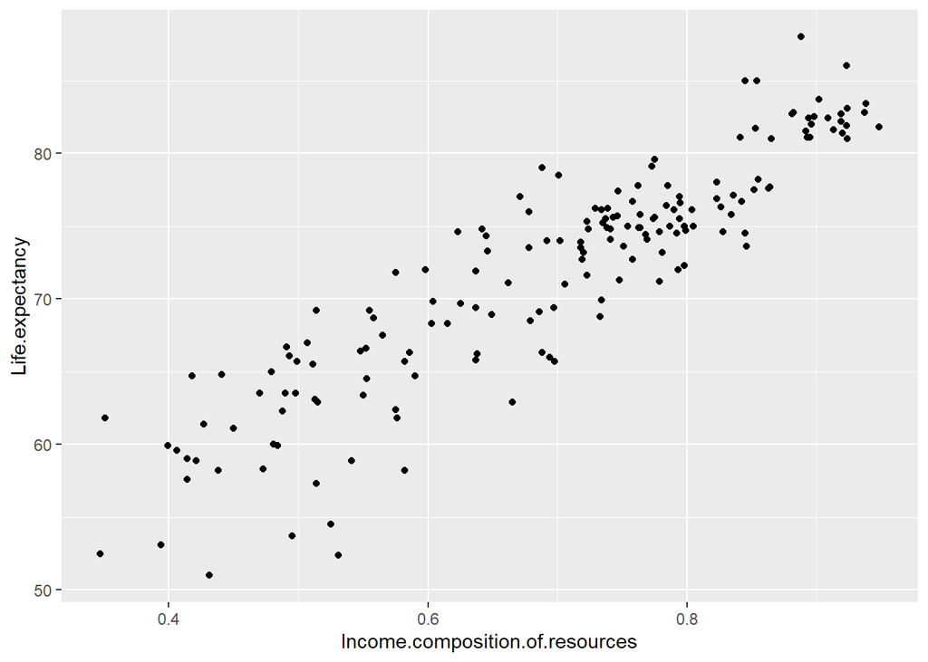

```r
library(tidyverse)
lifeexp <- read.csv("~/stat408/Homework1/Data/lifeexp.csv")
ggplot(data = lifeexp, aes(x=Income.composition.of.resources,y=Life.expectancy)) + geom_point()
```

- Using R, find the equation of the least squares regression line predicting life expectancy by ICOR.
- Our equation for least squares regression line is
- $\hat{Life.expectancy} = 39.264 + 46.906_{ICOR}$

```r
#fit for the regression model
mod <- lm(Life.expectancy ~ Income.composition.of.resources,data = lifeexp)
#view coefficients
summary(mod)$coefficients
```

```
                                Estimate Std. Error  t value     Pr(>|t|)
(Intercept)                     39.26420   1.203983 32.61193 7.994381e-75
Income.composition.of.resources 46.90661   1.693661 27.69539 1.028737e-64
```

- What do we expect the life expectancy to be for a country with a 0.7 ICOR? 0.3 ICOR?
- We expect the life expectancy for a country with a 0.7 ICOR to be 72.10 years
- We expect the life expectancy for a country with a 0.3 ICOR to be 53.34 years

```r
#data frame with values we want to check
newdata <- data.frame(Income.composition.of.resources = c(0.7,0.3))
#rename to ICOR bc its too long to type out
names(newdata)[names(newdata) == "ICOR"] <- "Income.composition.of.resources"
#predict life expectancy
pred <- predict(mod,newdata)
#print
pred
```

```
       1        2
72.09882 53.33618
```

- Calculate and interpret a 95% confidence interval for the slope of the least squares regression line.
- We are 95% confident that the slope of the least squares regression line is between 43.563 and 50.250

```r
confint(mod, level = 0.95)
```

```
                                   2.5 %   97.5 %
(Intercept)                     36.88741 41.64098
Income.composition.of.resources 43.56315 50.25006
```

```r
summary(mod)$coefficients
```

```
                                Estimate Std. Error  t value     Pr(>|t|)
(Intercept)                     39.26420   1.203983 32.61193 7.994381e-75
Income.composition.of.resources 46.90661   1.693661 27.69539 1.028737e-64
```

- Calculate and interpret a 90% prediction interval for the life expectancy of a randomly selected country with an ICOR of 0.79.
- We are 90% confident that the average life expectancy of any country with an Income Composition of Resources of 0.79 is between 70.743 and 81.898 years

```r
newdata <- data.frame(Income.composition.of.resources = 0.79)
prediction_int <- predict(mod,newdata,interval = "prediction", level = 0.90)
prediction_int
```

```
       fit     lwr      upr
1 76.32042 70.7433 81.89753
```

- Determine if the assumptions of homoscedasticity and normally distributed residuals are violated.
- Breusch-Pagan Test
  - $p-value = 6.245e-4 < \alpha = 0.05$
  - therefore homoscedasticity is violated
- Residual Plot
  - the residuals vs fitted plot shows a funnel growing smaller toward a higher age, therefore normally distributed are violated
- Q-Q Plot
  - the assumption of normality is not violated as there are only a small amount of deviations on each side of the plot.
- We cannot rely on the results as more than one test showed a violation of either homoscedasticity or normally distributed results.

```r
#load libraries
library(lmtest)
#check for homoscedasticity
bp_test <- bptest(mod)
p_value <- bptest(mod)$pvalue
bp_test
```

```
    studentized Breusch-Pagan test

data:  mod
BP = 11.701, df = 1, p-value = 0.0006245
```

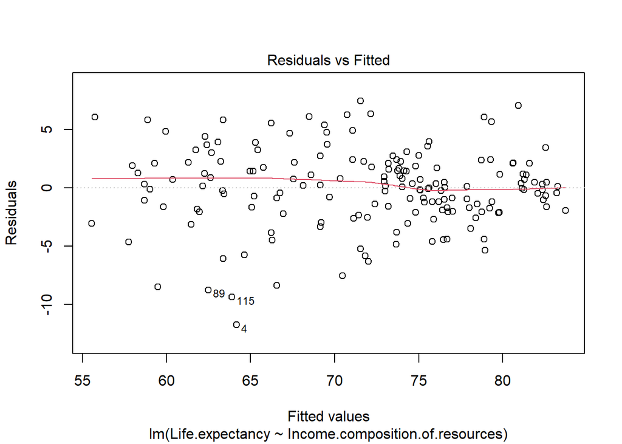

```r
#check for normally distributed results with Q-Q plot
plot(mod,1)
```

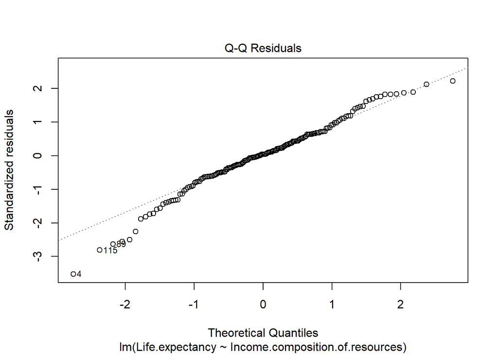

```r
plot(mod,2)
```